# Manipulando dados, data frames e listas

2016-09-23

## Agenda

- Selecionando e removendo subconjuntos de dados
- `within()`
- `with()` para especificar o escopo
- `tapply()`, `by()`, `aggregate()`
- `attach()` para especificar o caminho da base de dados

## Selecionando colunas/variáveis

### Gerando um pequeno data frame

```r
data.frame(x=LETTERS[1:6], a=1:6, b=2:7, c=3:8,
                 d=4:9, e=5:10, z = rep(c(1,2),3)) -> df

df
```

```
  x a b c d  e z
1 A 1 2 3 4  5 1
2 B 2 3 4 5  6 2
3 C 3 4 5 6  7 1
4 D 4 5 6 7  8 2
5 E 5 6 7 8  9 1
6 F 6 7 8 9 10 2
```

### Seleciona apenas as colunas `x` e `b`

```r
subset(df, select = c(x,b))
```

```
  x b
1 A 2
2 B 3
3 C 4
4 D 5
5 E 6
6 F 7
```

### Seleciona tudo, menos (-) as colunas `x` e `b`

```r
subset(df, select = -c(x,b) )
```

```
  a c d  e z
1 1 3 4  5 1
2 2 4 5  6 2
3 3 5 6  7 1
4 4 6 7  8 2
5 5 7 8  9 1
6 6 8 9 10 2
```

### Seleciona tudo, menos (-) as colunas `x` e `b`

```r
# Mais complexo, ou mais intuitivo?
excluir <- c("x","b")
df[ , !(names(df) %in% excluir)]
```

```
  a c d  e z
1 1 3 4  5 1
2 2 4 5  6 2
3 3 5 6  7 1
4 4 6 7  8 2
5 5 7 8  9 1
6 6 8 9 10 2
```

```r
reter <- "e"
df[ , reter, drop = FALSE]
```

```
   e
1  5
2  6
3  7
4  8
5  9
6 10
```

#### Qual é a lógica?

```r
a <- c("A", "C", "Z")
b <- c("A", "B", "C", "D", "E", "Z")

b %in% a
```

```
[1]  TRUE FALSE  TRUE FALSE FALSE  TRUE
```

### Seleciona tudo, menos (-) as colunas nas posições `1` a `2` e `4`

```r
# df[ linhas , colunas ]

df[ -c(1:2,4) ]
```

```
  b d  e z
1 2 4  5 1
2 3 5  6 2
3 4 6  7 1
4 5 7  8 2
5 6 8  9 1
6 7 9 10 2
```

- Observe que falta uma vírgula `df[, -c(1:2,4) ]`. Ainda assim, o R vai avaliar essa expressão corretamente, excluindo as colunas.

### Removendo colunas passando `NULL`

```r
df$x <- NULL
df
```

```
  a b c d  e z
1 1 2 3 4  5 1
2 2 3 4 5  6 2
3 3 4 5 6  7 1
4 4 5 6 7  8 2
5 5 6 7 8  9 1
6 6 7 8 9 10 2
```

### Removendo colunas passando `NULL`

```r
df[,c("x","a")] <- NULL

df
```

```
  b c d  e z
1 2 3 4  5 1
2 3 4 5  6 2
3 4 5 6  7 1
4 5 6 7  8 2
5 6 7 8  9 1
6 7 8 9 10 2
```

### Removendo colunas usando `within()` e função `rm()`

- `within()` é uma função usada para avaliar o ambiente dos dados, depois de ter executado `expr` (expressão), tentando aplicar as modificações no data frame.
- Podemos pensar em `within()` como uma função alternativa à `transform()`.

```r
within(df, rm(d, b))
```

```
  c  e z
1 3  5 1
2 4  6 2
3 5  7 1
4 6  8 2
5 7  9 1
6 8 10 2
```

## Selecionando casos

### Selecionando apenas casos em que `z == 1`

```r
(df2 <- subset(df, z==1))
```

```
  x a b c d e z
1 A 1 2 3 4 5 1
3 C 3 4 5 6 7 1
5 E 5 6 7 8 9 1
```

```r
# Mesmo resultado como com a função 'subset' acima
 df[ df$z == 1, ]
```

```
  x a b c d e z
1 A 1 2 3 4 5 1
3 C 3 4 5 6 7 1
5 E 5 6 7 8 9 1
```

## Selecionando casos e variáveis ao mesmo tempo

### Selecionando tudo, menos (-) z, para casos em que `z == 1`

```r
# subset(df, z == 1, select = c(x:e))

df2 <- subset(df, z == 1, select = -z)
df2
```

```
  x a b c d e
1 A 1 2 3 4 5
3 C 3 4 5 6 7
5 E 5 6 7 8 9
```

```r
df[ df$z==1 , c(1:6) ]
```

```
  x a b c d e
1 A 1 2 3 4 5
3 C 3 4 5 6 7
5 E 5 6 7 8 9
```

## Exemplos de uso da função `with()`

- Até o momento, nós temos basicamnete digitado o nome do data frame toda vez que queremos utilizar algumas de suas colunas/variáveis
- Isso é necessário porque as variáveis (colunas) não existem no ambiente de trabalho.
- Usando **with**`(dados, expr)` nos permite especificar que a `expr` (expressão) a seguir precisa ser avaliada em um ambiente que contenha os elementos de `dados` como variáveis.

## Exemplos de uso da função `with()`

```r
with(prefeitos, table(Exercício, Sexo))
```

```
         Sexo
Exercício Feminino Masculino Recusa
   Não         524      3505      0
   Recusa        0         0      2
   Sim         151      1388      0
```

```r
any(prefeitos$Exercício == "Sim" & prefeitos$Idade <= 25)
```

```
[1] TRUE
```

```r
with(prefeitos, any(Exercício == "Sim" & Idade <= 25)) #mesmo efeito
```

```
[1] TRUE
```

### Exemplos de uso da função `with()` com `tapply()`

```r
# ?tapply
tapply(X, INDEX, FUN = NULL, ..., simplify = TRUE)
```

- Executa uma função (mean, sum, median, count etc) para cada conjunto (não vazio) de valores dado por uma combinação única dos níveis de certos fatores. Pense em `tapply()` como uma forma generalizada da funcão `table()`.
- Usando nossos dados (prefeitos), vamos calcular a média de `Idade` por `Sexo`

```r
with(prefeitos, tapply(Idade, INDEX = list(Sexo),
                       FUN=mean, na.rm=TRUE))
```

```
 Feminino Masculino    Recusa
 47.03269  48.68819       NaN
```

```r
with(prefeitos, tapply(Idade, INDEX = list(Sexo, Exercício),
                       FUN=mean, na.rm=TRUE))
```

```
              Não Recusa      Sim
Feminino  46.7567     NA 47.98675
Masculino 48.2311     NA 49.83983
Recusa         NA    NaN       NA
```

### Exemplos de uso da função `with()` com `by()`

- `by()` é um *atalho* da função `tapply()` applicado à data frames.

```r
# ?by
by(data, INDICES, FUN, ..., simplify = TRUE)
```

```r
with(prefeitos, by(Idade, INDICES = list(Sexo),
                   FUN=mean, na.rm=TRUE))
```

```
: Feminino
[1] 47.03269
---------------------------------------------------------------------------------------
: Masculino
[1] 48.68819
---------------------------------------------------------------------------------------
: Recusa
[1] NaN
```

### Exemplos de uso da função `with()` com `aggregate()`

```r
# ?aggregate
aggregate(x, by, FUN, ..., simplify = TRUE, drop = TRUE)
```

- Divide seus dados em subconjuntos, calcula sumários estatísticos para cada, retornando o resultado em um formato conveniente.
- fórmula: `y ~ x + ... z` -> list(x, z)

```r
with(prefeitos,  aggregate(Idade ~ Sexo,
        FUN = mean))
```

```
       Sexo    Idade
1  Feminino 47.03269
2 Masculino 48.68819
```

### Observe o parâmetro `data`, usado para indicar o nome do data frame

```r
aggregate(Idade ~ Sexo, data = prefeitos,
          FUN = mean, na.rm=TRUE)
```

```
       Sexo    Idade
1  Feminino 47.03269
2 Masculino 48.68819
```

- Nos casos em que a função possui um parâmetro que você possa indicar o objeto de dados, usualmente `data`, `.data`, `df`, você não precisará usar `with()` ou `attach()`.

## Função `attach()` e `detach()` para data frames

- O uso da função `with()` deixa a programação mais simples e fácil de ler. No entando, se você preferir ter os dados disponíveis no mesmo ambiente em que executa o trabalho, a função que você precisa é `attach()`.

```r
attach(prefeitos)
# Não é necessário informar o nome dos dados
aggregate(Idade ~ Sexo, FUN = mean, na.rm = TRUE)
```

```
       Sexo    Idade
1  Feminino 47.03269
2 Masculino 48.68819
```

### Exemplos de uso da função `attach()`

```r
attach(prefeitos)
table(Exercício, Sexo)
```

```
         Sexo
Exercício Feminino Masculino Recusa
   Não         524      3505      0
   Recusa        0         0      2
   Sim         151      1388      0
```

### Retirando uma base de dados do caminho

```r
detach(prefeitos)
```

## Retirando objetos do ambiente de trabalho

```r
## Onde o R procura por objetos
search()
```

```
 [1] ".GlobalEnv"        "prefeitos"         "package:readxl"    "package:stats"     "package:graphics"
 [6] "package:grDevices" "package:utils"     "package:datasets"  "package:methods"   "Autoloads"
[11] "package:base"
```

```r
ls() # objetos no chamado Global Environment (Workspace)
```

```
[1] "a"         "b"         "df"        "df2"       "endereço"  "excluir"   "prefeitos" "reter"
```

```r
ls(pos=2) # objects in package 'foreign'
```

```
[1] "Escolaridade" "Exercício"    "Idade"        "Partido"      "Rótulo"       "Sexo"
```

```r
# rm(list = ls())

rm(prefeitos)
```

```r
ls()
```

```
[1] "a"        "b"        "df"       "df2"      "endereço" "excluir"  "reter"
```

```r
rm(list=ls())
```

```r
ls()
```

```
character(0)
```

## Gerando categorias com a função `cut()`

### Obtendo alguns dados

```r
library(readxl, quietly = TRUE)
endereço = "./data/Prefeitos.xlsx"
prefeitos <- data.frame(read_excel(endereço))

head(prefeitos, 3)
```

```
  Rótulo Exercício      Sexo Idade            Escolaridade Partido
1 110001       Não Masculino    55 Ensino médio incompleto    PMDB
2 110002       Não Masculino    56   Ensino médio completo     PMN
3 110003       Sim Masculino    42           Pós-graduação     PTB
```

### Fatiando dados numéricos em categorias (factors)

```r
 prefeitos$Idade.cat <- cut(prefeitos$Idade,
                      c(-Inf, 25, 35, 45, 55, 65, Inf),
                      labels=c('<=25', '25-35', '35-45',
                      '45-55', '55-65', '65=>'))
```

```r
head(prefeitos[,-1])
```

```
  Exercício      Sexo Idade             Escolaridade Partido Idade.cat
1       Não Masculino    55  Ensino médio incompleto    PMDB     45-55
2       Não Masculino    56    Ensino médio completo     PMN     55-65
3       Sim Masculino    42            Pós-graduação     PTB     35-45
4       Sim Masculino    67 Ensino superior completo      PT      65=>
5       Não Masculino    55 Ensino superior completo      PP     45-55
6       Sim Masculino    44    Ensino médio completo      PP     35-45
```

### `cut()` no ambiente da funcão `transform()`

```r
prefeitos <- transform(prefeitos,
                      Idade.cat2 = cut(Idade,
                      c(-Inf, 25, 35, 45, 55, 65, Inf),
                      labels=c('<=25', '25-35', '35-45',
                      '45-55', '55-65', '65=>')))

head(prefeitos[,-c(1,2)])
```

```
       Sexo Idade             Escolaridade Partido Idade.cat Idade.cat2
1 Masculino    55  Ensino médio incompleto    PMDB     45-55      45-55
2 Masculino    56    Ensino médio completo     PMN     55-65      55-65
3 Masculino    42            Pós-graduação     PTB     35-45      35-45
4 Masculino    67 Ensino superior completo      PT      65=>       65=>
5 Masculino    55 Ensino superior completo      PP     45-55      45-55
6 Masculino    44    Ensino médio completo      PP     35-45      35-45
```

### Resultados

```r
with(prefeitos, table(Idade.cat))
```

```
Idade.cat
 <=25 25-35 35-45 45-55 55-65  65=>
   39   559  1501  2125  1047   280
```

- Proportions table `prop.table()`

```r
with(prefeitos, prop.table(table(Idade.cat)))
```

```
Idade.cat
       <=25       25-35       35-45       45-55       55-65        65=>
0.007025761 0.100702576 0.270401729 0.382813907 0.188614664 0.050441362
```

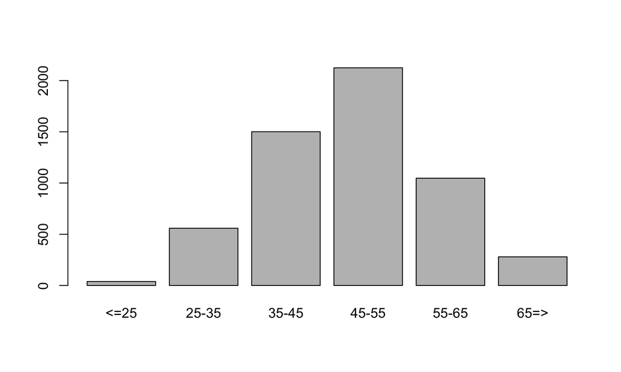

```r
tab <- with(prefeitos, table(Idade.cat))

barplot(tab)
```

## Declarações condicionais `if()/ifelse()`

- Frequentemente, queremos que o nosso código seja executado de forma diferente, dependendo dos atributos disponíveis.
- Exemplo: Calcular a menção de um estudante, dependendo da somatória de seus pontos.
- `if` nota >= 90, atribuir A
- Ou, `if` nota >= 80, atribuir B
- Ou, `if` nota >= 70, atribuir C
- Para todo o resto, `else`, atribuir F
- Para programar coisas como estas, usamos testes lógicos `if-else`.

## Seleção condicional de elementos

### Se menor ou igual a 25, TRUE, FALSE

```r
prefeitos$Jovens <- ifelse(prefeitos$Idade <= 25, 1, 0)

head(prefeitos[,-c(1,2,3)])
```

```
  Idade             Escolaridade Partido Idade.cat Idade.cat2 Jovens
1    55  Ensino médio incompleto    PMDB     45-55      45-55      0
2    56    Ensino médio completo     PMN     55-65      55-65      0
3    42            Pós-graduação     PTB     35-45      35-45      0
4    67 Ensino superior completo      PT      65=>       65=>      0
5    55 Ensino superior completo      PP     45-55      45-55      0
6    44    Ensino médio completo      PP     35-45      35-45      0
```

### Se menor ou igual a 25, TRUE, FALSE (Character)

```r
prefeitos$Jovens <- ifelse(prefeitos$Idade <= 25, "Sim", "Não" )

head(prefeitos[,-c(1,2,3)])
```

```
  Idade             Escolaridade Partido Idade.cat Idade.cat2 Jovens
1    55  Ensino médio incompleto    PMDB     45-55      45-55    Não
2    56    Ensino médio completo     PMN     55-65      55-65    Não
3    42            Pós-graduação     PTB     35-45      35-45    Não
4    67 Ensino superior completo      PT      65=>       65=>    Não
5    55 Ensino superior completo      PP     45-55      45-55    Não
6    44    Ensino médio completo      PP     35-45      35-45    Não
```

### `ifelse()` no ambiente da funcão `transform()`

```r
prefeitos <- transform(prefeitos,
  Superior = ifelse(
  Escolaridade == "Pós-graduação" |
  Escolaridade == "Ensino superior completo", 1, 0),
  Exercício = as.factor(Exercício))

head(prefeitos[,-c(1,2,3,4)])
```

```
              Escolaridade Partido Idade.cat Idade.cat2 Jovens Superior
1  Ensino médio incompleto    PMDB     45-55      45-55    Não        0
2    Ensino médio completo     PMN     55-65      55-65    Não        0
3            Pós-graduação     PTB     35-45      35-45    Não        1
4 Ensino superior completo      PT      65=>       65=>    Não        1
5 Ensino superior completo      PP     45-55      45-55    Não        1
6    Ensino médio completo      PP     35-45      35-45    Não        0
```

## Recodificação básica com a função `replace()`

```r
x <- c(1, 2, NA, 2, 1, 10)
x
```

```
[1]  1  2 NA  2  1 10
```

```r
x == 2
```

```
[1] FALSE  TRUE    NA  TRUE FALSE FALSE
```

```r
which(x==2)
```

```
[1] 2 4
```

### Ou seja, pegue 'x' e substitua valores iguais 2 por 20

```r
y <-replace(x, which(x==2), 20)
y
```

```
[1]  1 20 NA 20  1 10
```

## Dados ausentes (missing)

### O símbolo do R para dados ausentes é NA (Not Available)

##### NA é um elemento de 'x'?

```r
x
```

```
[1]  1  2 NA  2  1 10
```

```r
is.na(x)
```

```
[1] FALSE FALSE  TRUE FALSE FALSE FALSE
```

##### `!` significa "não"

```r
!is.na(x)
```

```
[1]  TRUE  TRUE FALSE  TRUE  TRUE  TRUE
```

##### substituir NA por 99

```r
replace(x, which(is.na(x)), 99) -> v; v
```

```
[1]  1  2 99  2  1 10
```

##### substituir 1 por NA

```r
replace(x, which(x==1), NA) -> z; z
```

```
[1] NA  2 NA  2 NA 10
```

#### Retorne apenas valores válidos (e informação extra sobre o objeto)

#### Informa a posição da ocorrência

```r
x; na.omit(x)
```

```
[1]  1  2 NA  2  1 10
```

```
[1]  1  2  2  1 10
attr(,"na.action")
[1] 3
attr(,"class")
[1] "omit"
```

## Substituindo valores de um data frame

```r
prefeitos <- transform(prefeitos,
        Exercício = replace(Exercício, which(Exercício == "Recusa"), NA),
        Sexo = replace(Sexo, which(Sexo == "Recusa"), NA),
        Idade = replace(Idade, which(Idade == "Recusa"), NA),
        Partido = replace(Partido, which(Partido == "Recusa"), NA),
        Escolaridade = replace(Escolaridade,
                               which(Escolaridade == "Recusa"), NA))

table(is.na(prefeitos))
```

```
FALSE  TRUE
55616    84
```

## Gráfico de barras

[figure not shown]

```r
tab <- with(prefeitos, table(Exercício, Sexo));

barplot(tab, main = "Prefeitos em excercício por sexo",
legend.text = c("Sim", "Não"), args.legend = list(x = "topleft"))
```

## Gráfico de densidade condicional

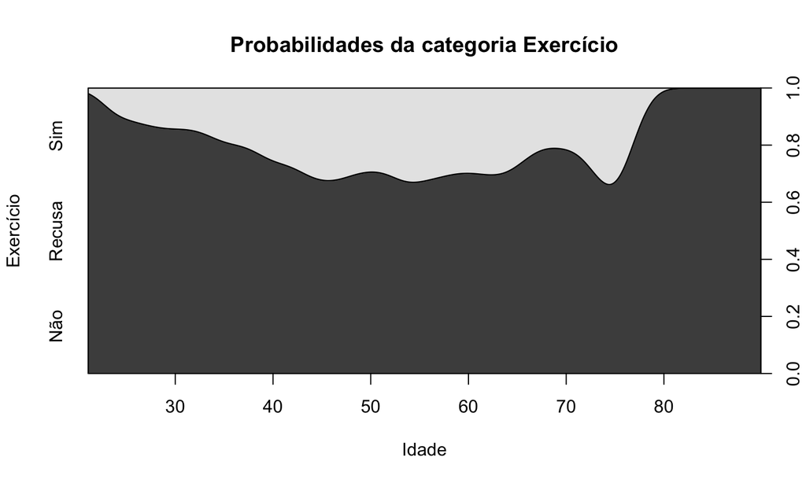

```r
cdplot(Exercício ~ Idade, data=prefeitos,
       main = "Probabilidades da categoria Exercício")
```

- Descreve como a distribuição condicional de uma variável categórica (fator) varia vis-à-vis uma variável númerica